# Homework 6

Jess Wikle

2/19/2020

## Simulating and fitting data distributions

##### Packages

```r
library(ggplot2) # for graphics
library(MASS) # for maximum likelihood estimation
```

##### Read in data

```r
# read in data
# this is data contains aboveground biomass in living trees, dead trees, and downed woody material in 198 plots at Second College Grant ASCC site, New Hampshire
z <- read.table("my_data.csv",header=FALSE,sep=",", stringsAsFactors=FALSE)
str(z)
```

```
## 'data.frame':    197 obs. of  2 variables:
##  $ V1: int  1 2 3 4 5 6 7 8 9 10 ...
##  $ V2: num  189 177 142 202 169 ...
```

```r
summary(z)
```

```
##        V1            V2
##  Min.   :  1   Min.   : 15.22
##  1st Qu.: 50   1st Qu.:122.05
##  Median : 99   Median :164.54
##  Mean   : 99   Mean   :160.55
##  3rd Qu.:148   3rd Qu.:205.71
##  Max.   :197   Max.   :410.98
```

```r
names(z) <- list("ID","myVar")
z <- z[z$myVar>0,]
str(z)
```

```
## 'data.frame':    197 obs. of  2 variables:
##  $ ID   : int  1 2 3 4 5 6 7 8 9 10 ...
##  $ myVar: num  189 177 142 202 169 ...
```

```r
summary(z$myVar)
```

```
##    Min. 1st Qu.  Median    Mean 3rd Qu.    Max.
##   15.22  122.05  164.54  160.55  205.71  410.98
```

## 3. Run the code on my data

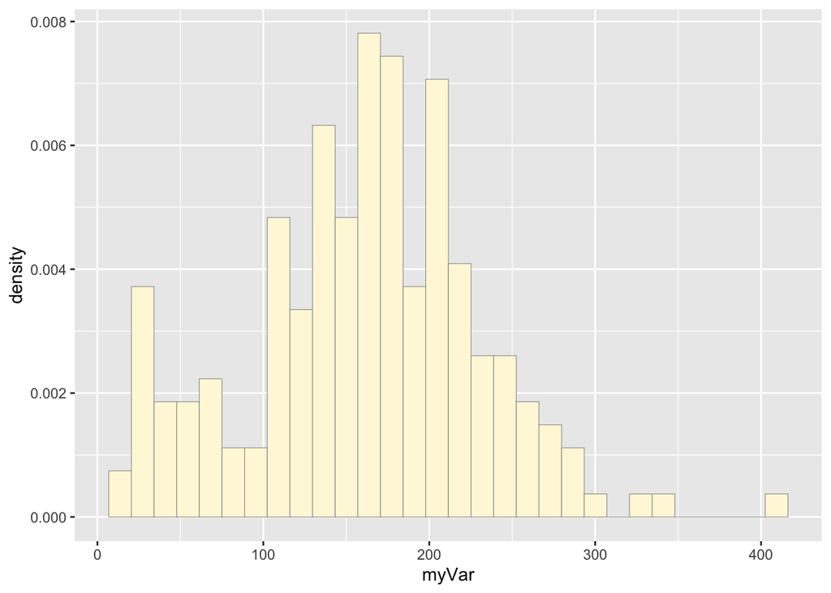

```r
# plot histogram of the data
p1 <- ggplot(data=z, aes(x=myVar, y=..density..)) + # y = ..density.. rescales the y-axis of the histogram from counts to density, so that area under the histogram = 1
  geom_histogram(color="grey60",fill="cornsilk",size=0.2)
print(p1)
```

#### Add empirical density curve

This smooths out the shape of the histogram, but doesn’t assume any particular probability distribution.

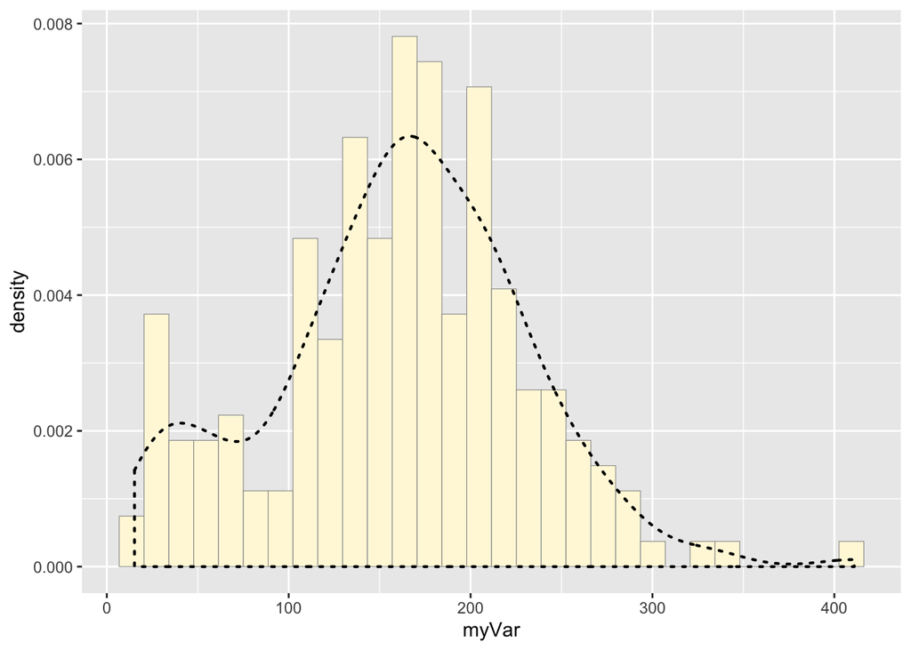

```r
p1 <-  p1 +  geom_density(linetype="dotted",size=0.75)
print(p1)
```

#### Get maximum likelihood paramenters for normal distribution

```r
normPars <- fitdistr(z$myVar,"normal") # fits most likely normal distribution parameters to my data
print(normPars)
```

```
##       mean          sd
##   160.553655    69.557757
##  (  4.955785) (  3.504269)
```

```r
str(normPars) # list that includes mean, sd, variance-covariance, n, and loglikelihood
```

```
## List of 5
##  $ estimate: Named num [1:2] 160.6 69.6
##   ..- attr(*, "names")= chr [1:2] "mean" "sd"
##  $ sd      : Named num [1:2] 4.96 3.5
##   ..- attr(*, "names")= chr [1:2] "mean" "sd"
##  $ vcov    : num [1:2, 1:2] 24.6 0 0 12.3
##   ..- attr(*, "dimnames")=List of 2
##   .. ..$ : chr [1:2] "mean" "sd"
##   .. ..$ : chr [1:2] "mean" "sd"
##  $ n       : int 197
##  $ loglik  : num -1115
##  - attr(*, "class")= chr "fitdistr"
```

```r
normPars$estimate["mean"] # note structure of getting a named attribute
```

```
##     mean
## 160.5537
```

#### Plot normal probability density

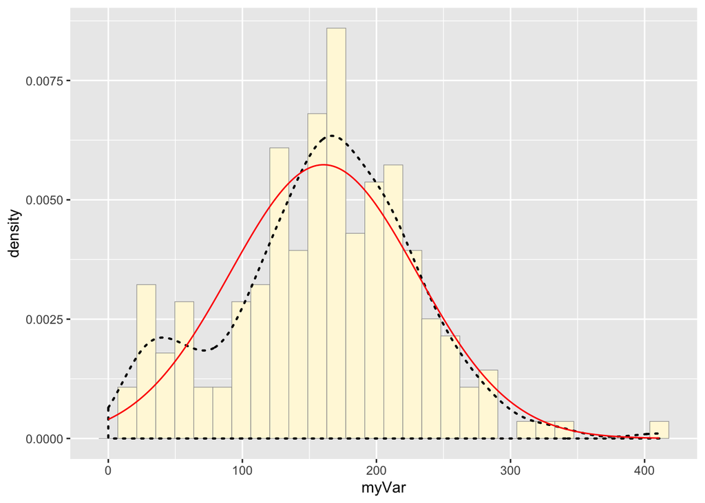

```r
# mean and sd from above ML parameter estimation
meanML <- normPars$estimate["mean"]
sdML <- normPars$estimate["sd"]

xval <- seq(0,max(z$myVar),len=length(z$myVar)) # sets x-value from 0 to the max of my variable, at length of my variable

 stat <- stat_function(aes(x = xval, y = ..y..), fun = dnorm, colour="red", n = length(z$myVar), args = list(mean = meanML, sd = sdML)) # stat_function is a function within ggplot that makes it easy to superimpose a function on top of an existing plot
# In this case, dnorm is our function, giving the probability density for the normal distribution
 p1 + stat
```

#### Plot exponential probability density

```r
expoPars <- fitdistr(z$myVar,"exponential") # same as above fitdistr, but now with exponential distribution
rateML <- expoPars$estimate["rate"] # pull ML rate out of list

stat2 <- stat_function(aes(x = xval, y = ..y..), fun = dexp, colour="blue", n = length(z$myVar), args = list(rate=rateML)) # same as above, but now function is dexp for exponential distribution
 p1 + stat + stat2
```

[figure not shown]

#### Uniform probability density

```r
# don't need to use fitdistr because ML parameters are just minimum and maximim of the data
stat3 <- stat_function(aes(x = xval, y = ..y..), fun = dunif, colour="darkgreen", n = length(z$myVar), args = list(min=min(z$myVar), max=max(z$myVar)))
 p1 + stat + stat2 + stat3
```

[figure not shown]

#### Gamma probability density

```r
gammaPars <- fitdistr(z$myVar,"gamma")
shapeML <- gammaPars$estimate["shape"]
rateML <- gammaPars$estimate["rate"]

stat4 <- stat_function(aes(x = xval, y = ..y..), fun = dgamma, colour="brown", n = length(z$myVar), args = list(shape=shapeML, rate=rateML))
 p1 + stat + stat2 + stat3 + stat4
```

[figure not shown]

#### Beta probability density

This is on its own plot because the data need to be rescaled to 0 -1.

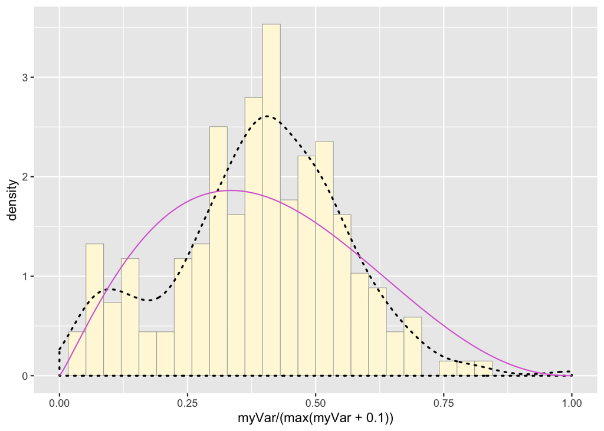

```r
pSpecial <- ggplot(data=z, aes(x=myVar/(max(myVar + 0.1)),  y=..density..)) + # this rescales data
  geom_histogram(color="grey60",fill="cornsilk",size=0.2) +
  xlim(c(0,1)) +
  geom_density(size=0.75,linetype="dotted")

betaPars <- fitdistr(x=z$myVar/max(z$myVar + 0.1),start=list(shape1=1,shape2=2),"beta") # fits beta to scaled data
shape1ML <- betaPars$estimate["shape1"] #extract components
shape2ML <- betaPars$estimate["shape2"]

statSpecial <- stat_function(aes(x = xval, y = ..y..), fun = dbeta, colour="orchid", n = length(z$myVar), args = list(shape1=shape1ML,shape2=shape2ML))
pSpecial + statSpecial
```

## 4. Take a look at final graph and see which distribution fits the data best

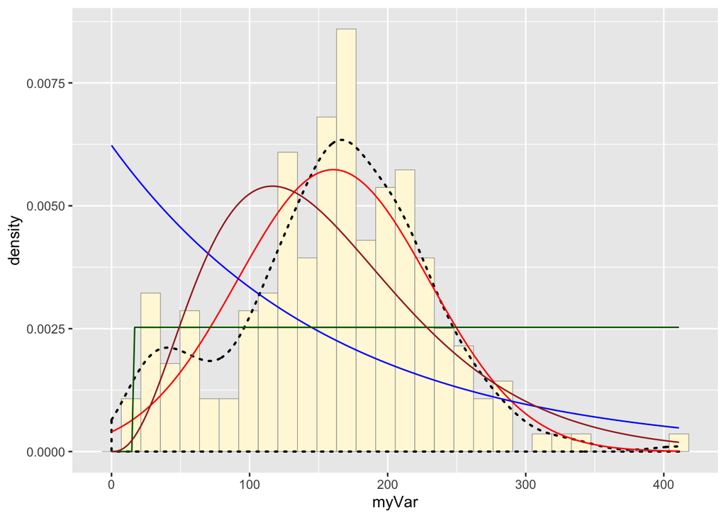

```r
p1 + stat + stat2 + stat3 + stat4
```

The normal distribution (red line) appears to fit my data best.

## 5. Using the best-fitting distribution, go back to the code and get the maximum likelihood parameters. Use those to simulate a new data set, with the same length as your original vector, and plot that in a histogram and add the probability density curve. Right below that, generate a fresh histogram plot of the original data, and also include the probability density curve.

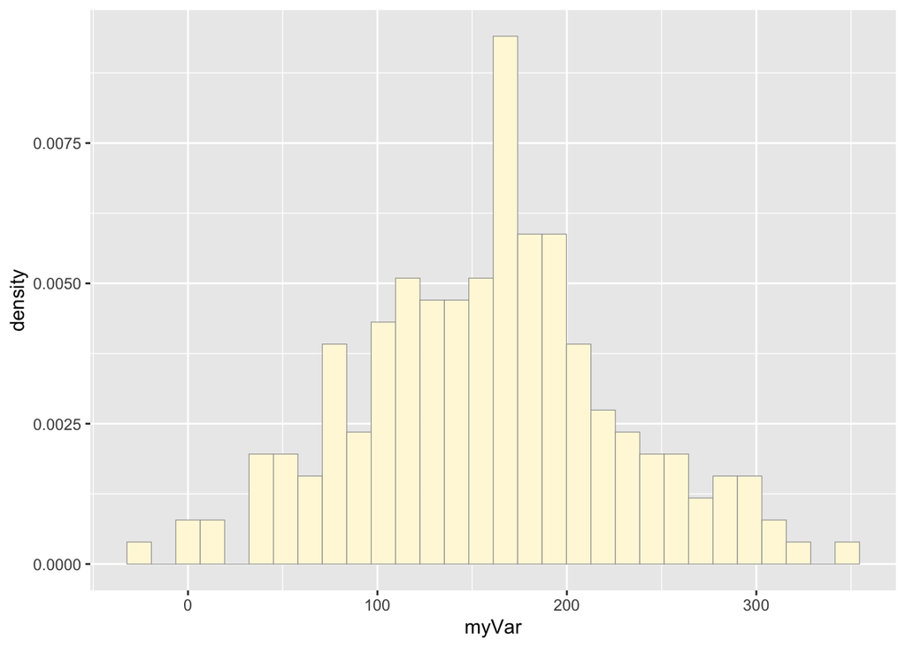

```r
# simulate new dataset
z2 <- rnorm(198, mean = meanML, sd = sdML)
# add ID column
Id <- c(1:198)
# combine into dataframe
z2 <- data.frame(z2, Id)
# name columns
names(z2) <- list("myVar","ID")
# create histogram
p2 <- ggplot(data=z2, aes(x=myVar, y=..density..)) +
  geom_histogram(color="grey60",fill="cornsilk",size=0.2)
print(p2)
```

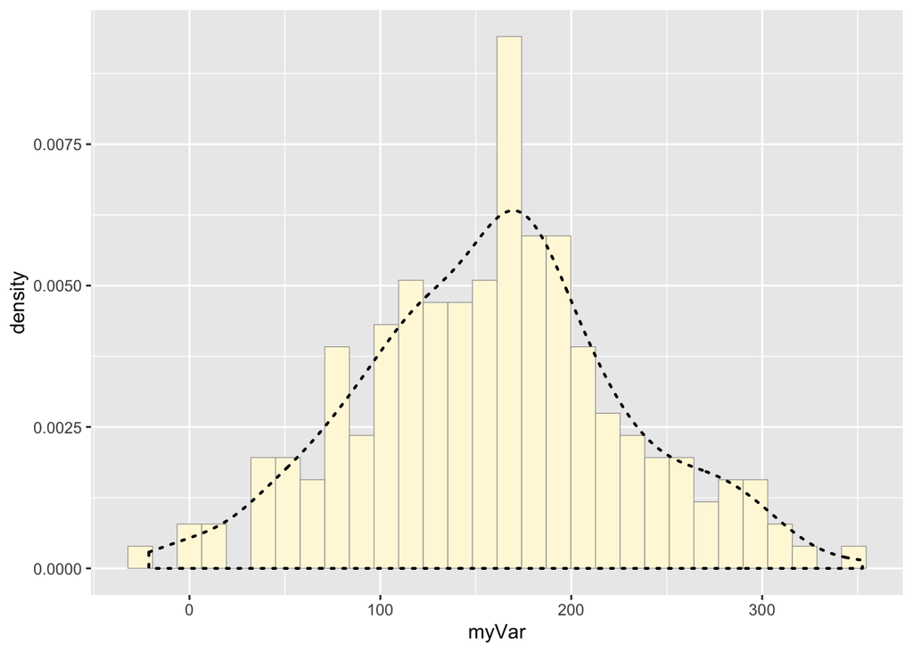

```r
# add probability density curve
p2 <-  p2 +  geom_density(linetype="dotted",size=0.75)
print(p2)
```

```r
library(patchwork)
```

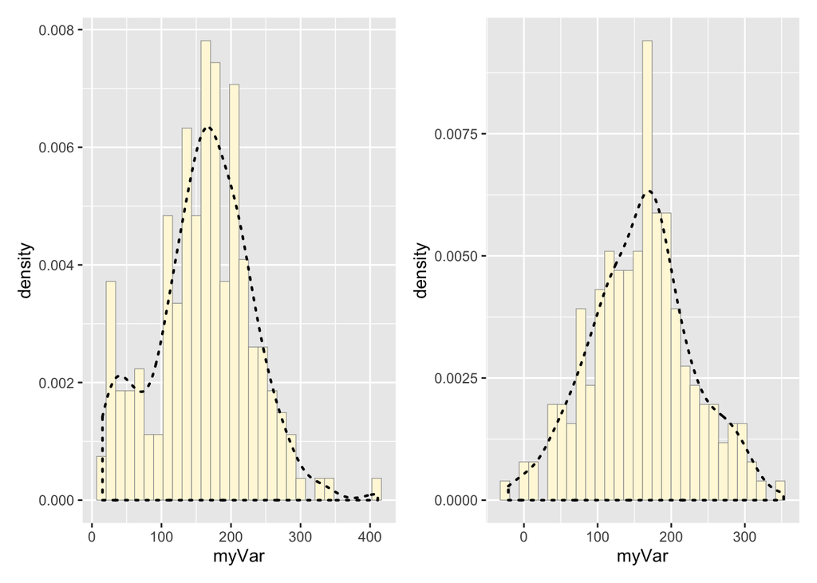

```r
# look at both histograms side by side
p1 + p2
```

##### How do the two histogram profiles compare? Do you think the model is doing a good job of simulating realistic data that match your original measurements? Why or why not?

The are somewhat similar. The model simulated data with less variation than my data, but with more than I might have expected with a data simulation. I think it does a reasonable job of simulating realistic data, but my data isn’t completely normally distributed, so the normally distributed simulation doesn’t capture that.